# About the project

```r
# This is a so-called "R chunk" where you can write R code.

date()
```

```
## [1] "Tue Nov  8 12:48:46 2022"
```

The text continues here.

Hello, testing this!! ZOM!

Hello World, why are my commits not pushing through?

I *was* feeling happy and motivated! I got R, Rstudio, Git and Github up and running. Now I see my commits on Github but unfortunately my diary is not updating. Apparently, according to Github, the updating of a public page may take up to 24h. I feel like that is a very long time and I wonder if commits made directly on Github (not remotely with Git) would take as long.

I discovered the IODS-course on an email sent to all doctoral schools. I’m looking forward to learning about rMarkdown, project management in Github, and clustering.

Looking forward to this course!

**Update**: I got to attend our course IT-help-zoom. It was great! Even though my diary did not update despite our efforts. Apparently everything looks good and my diary should update if I wait some more. The info was reassuring so I’ll be waiting more serenely now!

Meanwhile, I’ll keep myself busy with [R for Health Data Science](https://argoshare.is.ed.ac.uk/healthyr_book/) as suggested during the course introduction lecture. It seems very informative and easy to read. I’m somewhat familiar with R but I haven’t used tidyverse much. Piping gets me a bit confused but it’s my favorite topic! Exercise Set 1 is interesting and useful, but it did require some package installations, but I’m good to go now and ready to keep working now that all packages are…packed along!

**Update v2** We did it! The diary has updated itself after 2h 13min of me patiently waiting (and eagerly non-stop pushing new commits).

**Link to my Github repo** https://github.com/hsanez/IODS-project

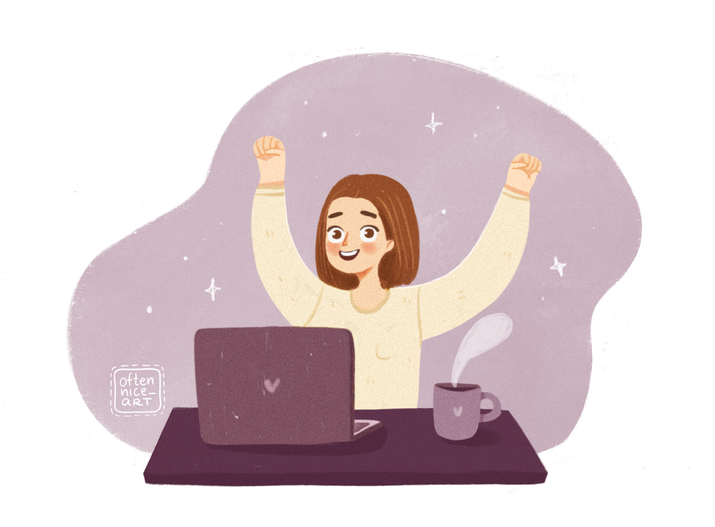

Yay! A happy girl at a laptop By Marina Vishtak

## Resources

- [R](https://www.r-project.org)
- [RStudio](https://www.rstudio.com)
- [GitHub](https://github.com)
- [Git](https://git-scm.com)
- [R for Health Data Science](https://argoshare.is.ed.ac.uk/healthyr_book/)
- [Beautiful art by Marina Vishtak](https://dribbble.com/shots/15062030-Yay-A-happy-girl-at-a-laptop/attachments/6789876?mode=media)